# NLSY Data Exploration

2023-10-07

# NLSY Data

## Sample Composition

The racial and ethnic composition of the sample is following:

|  | Non-Hispanic | Hispanic | NA |
| --- | --- | --- | --- |
| White | 4406 | 819 | 7 |
| Black or African American | 2333 | 54 | 1 |
| American Indian, Eskimo, or Aleut | 43 | 18 | 0 |
| Asian or Pacific Islander | 156 | 4 | 0 |
| Something else? (SPECIFY) | 119 | 944 | 0 |
| NA | 4 | 60 | 16 |

Because the sample sizes for people who identify as American Indian, Eskimo, or Aleut and Asian or Pacific Islander are small, we group them with others. We also drop those who miss race information.

|  | Non-Hispanic | Hispanic |
| --- | --- | --- |
| White | 4406 | 819 |
| Black | 2333 | 54 |
| Other | 318 | 966 |

## Wealth and Income

The number of observations with missing parental wealth is 2327, those that are missing parental income is 2361 and those that are missing either one is 3106.

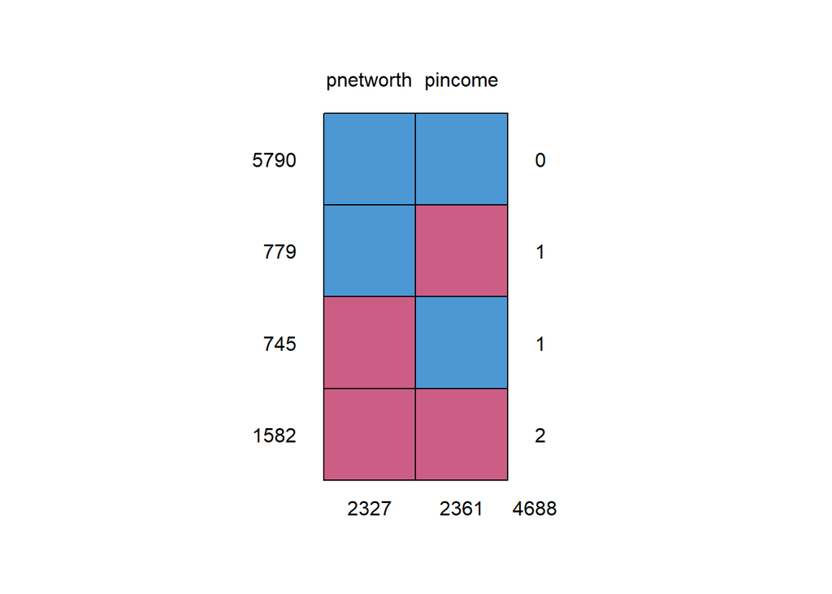

Missing Values for Parents’ Net Worth and Income

```
##      pnetworth pincome
## 5790         1       1    0
## 779          1       0    1
## 745          0       1    1
## 1582         0       0    2
##           2327    2361 4688
```

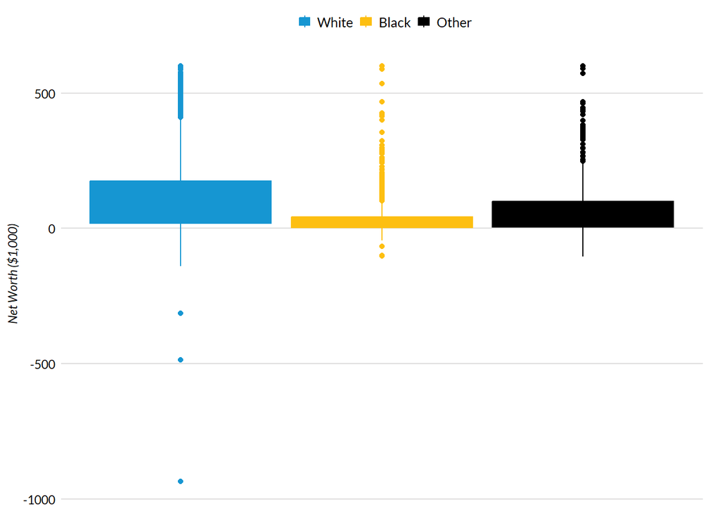

Distribution of Parents’ Net Worth by Race (Thousands od Dollars)

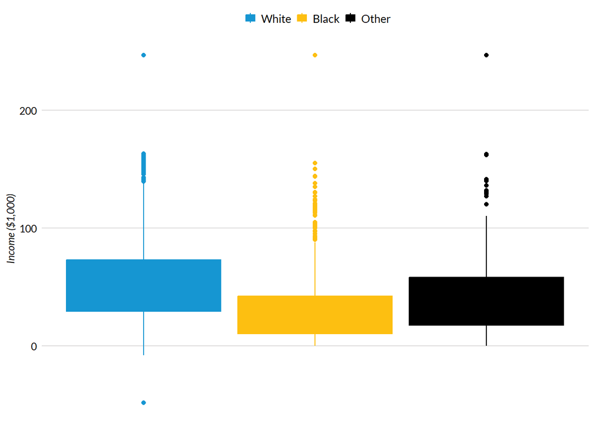

Distribution of Parents’ Income by Race (Thousands od Dollars)

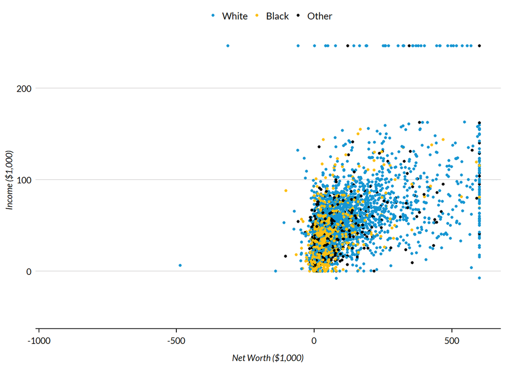

Parents’ Net Worth and Gross Income by Race (Thousands of Dollars)

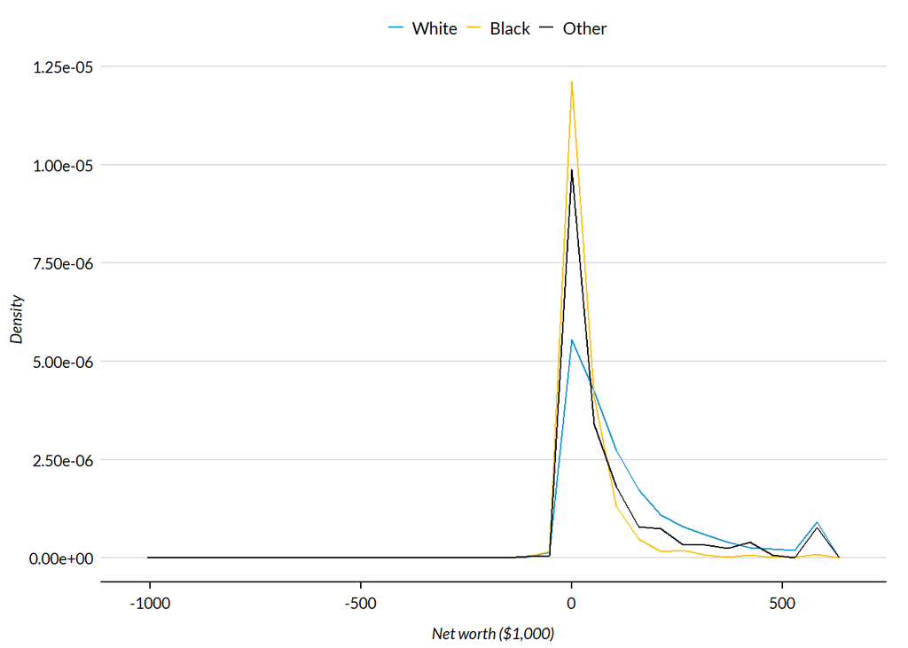

Distribution of Parents’ Net Worth by Race (Thousands of Dollars)

# College Education

## Ever Attended College

```
##
##    0    1
## 3606 5378
```

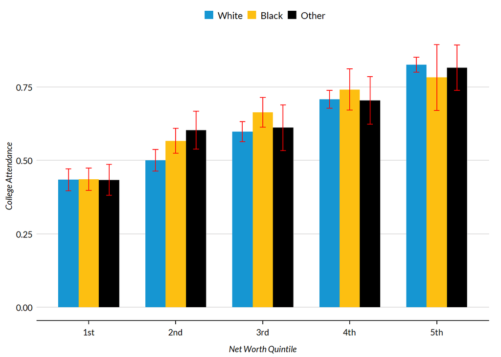

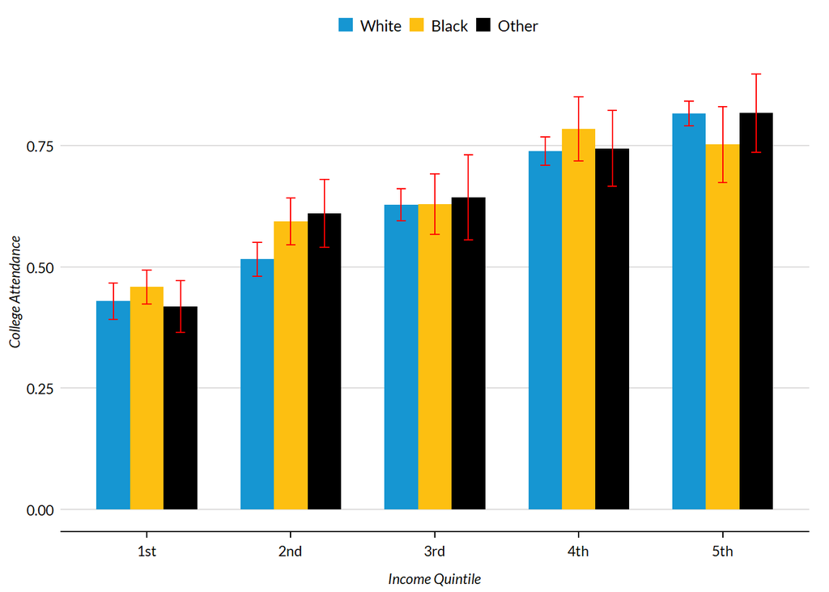

## College Enrollment History

This chart shows the number of college years completed in every year of the survey since the graduation from high school. Each row represents an NLSY participant who graduated from high school and the x-axis represents the number of years since the graduation. Cells are color-coded according to the number of years of college completed.

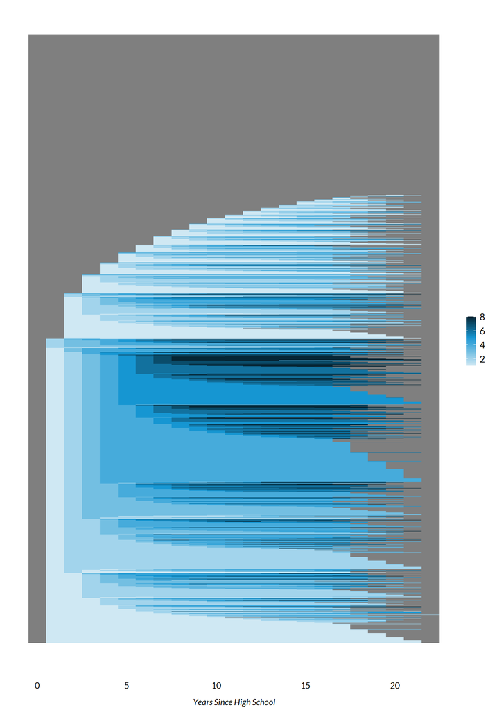

# Student loans

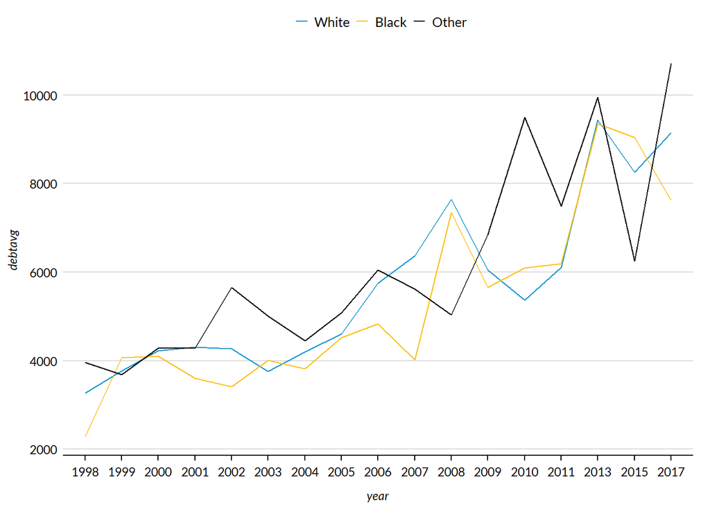

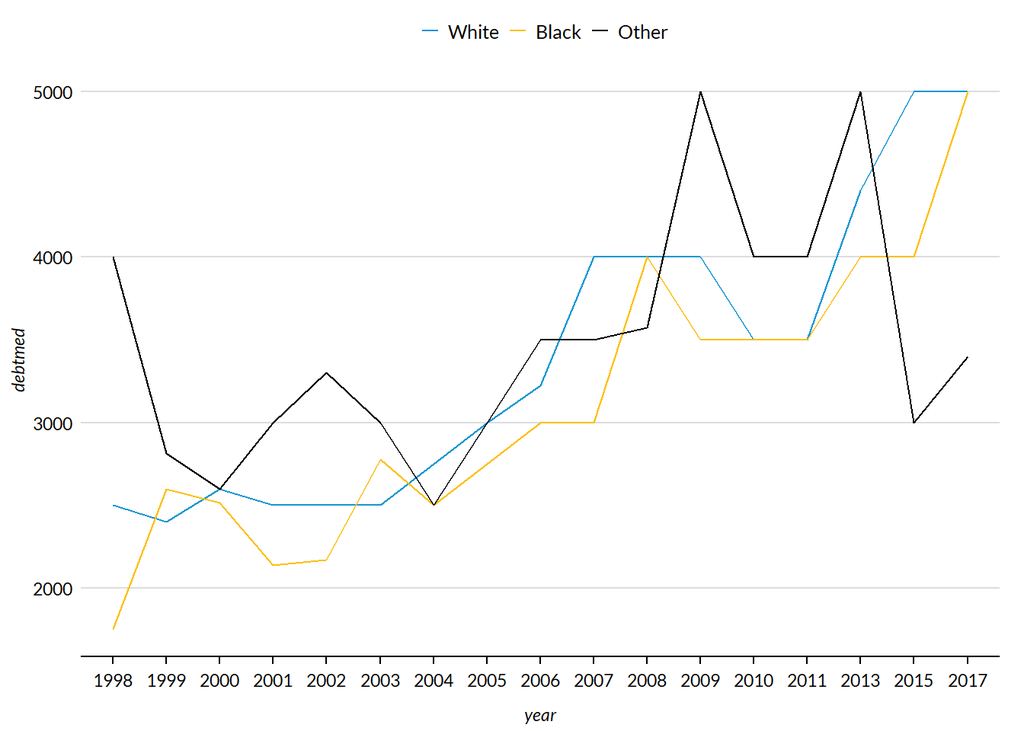

# Housing

## Living with Parents

The NLSY survey defines independence fairly broadly. To better understand the degree of dependence on parents, we construct a variable that is true if any of the following lives in the same household as the participant:

- Mother,
- Father,
- Adoptive mother,
- Adoptive father,
- Step-mother,
- Step-father,
- Foster mother,
- Foster father

From https://www.nlsinfo.org/content/cohorts/nlsy97/topical-guide/income/income:

> To be considered independent, a respondent had at least one of these characteristics: was age 18 or older, had a child, was enrolled in a 4-year college, was or had been married or was in a marriage-like relationship (defined in rounds 1-8 as a sexual relationship where partners of the opposite sex live together) at the time of the survey, was no longer enrolled in school, or was not living with any parents or parent-figures. Beginning in round 8, all respondents were classified as independent.

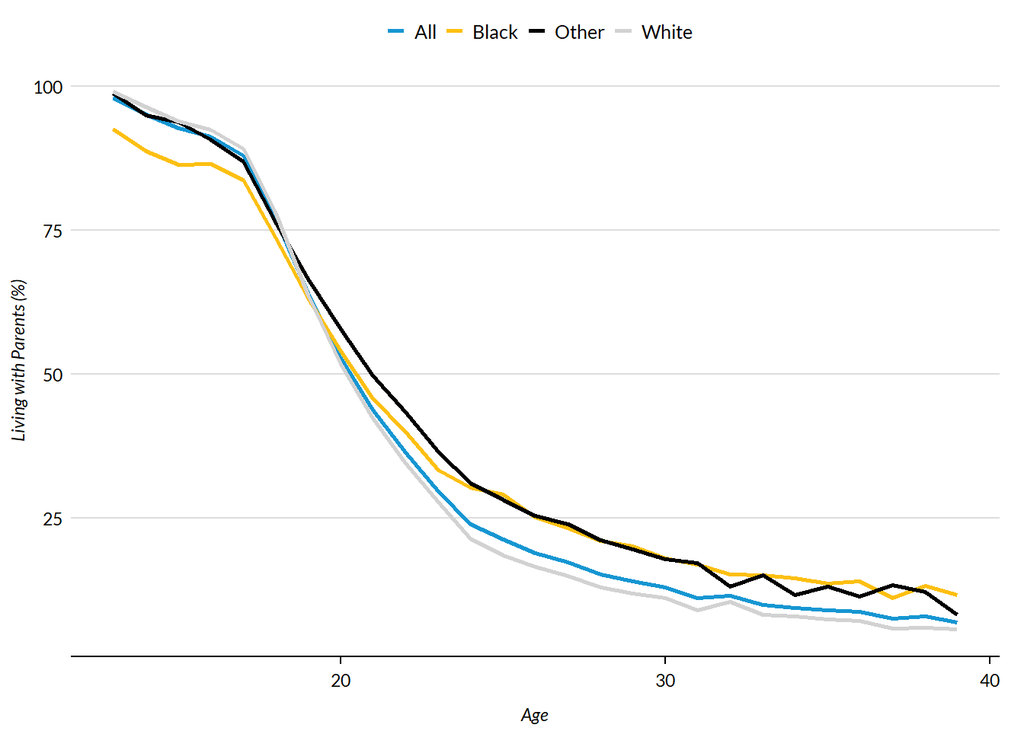